# Projet 5 - Segmenter des clients d'un site e-commerce

#### Cluster 1

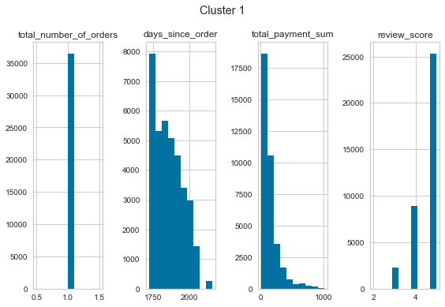

```python
# Cluster 1
fig, (ax1, ax2, ax3, ax4) = plt.subplots(1, 4)
fig.suptitle('Cluster 1')
ax1.hist(df_1['total_number_of_orders'])
ax1.set_title('total_number_of_orders')
ax2.hist(df_1['days_since_order'])
ax2.set_title('days_since_order')
ax3.hist(df_1['total_payment_sum'])
ax3.set_title('total_payment_sum')
ax4.hist(df_1['review_score'])
ax4.set_title('review_score')
plt.tight_layout()
plt.show()
```

[figure not shown]

```python
plt.figure(figsize=(8, 7))
sns.scatterplot(data=df_1,
                x='days_since_order', y='total_payment_sum',
                hue='review_score', palette='pastel')
plt.xlabel('Recency')
plt.ylabel('Monetary value')
plt.legend()
plt.title('Recency vs. Monetary for cluster 1, according to their review score')
plt.show()
```

#### Cluster 2

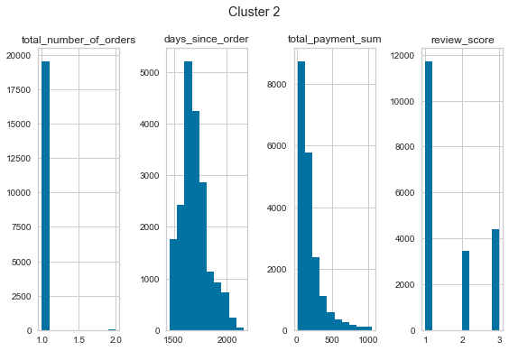

```python
# Cluster 2
fig, (ax1, ax2, ax3, ax4) = plt.subplots(1, 4)
fig.suptitle('Cluster 2')
ax1.hist(df_2['total_number_of_orders'])
ax1.set_title('total_number_of_orders')
ax2.hist(df_2['days_since_order'])
ax2.set_title('days_since_order')
ax3.hist(df_2['total_payment_sum'])
ax3.set_title('total_payment_sum')
ax4.hist(df_2['review_score'])
ax4.set_title('review_score')
plt.tight_layout()
plt.show()
```

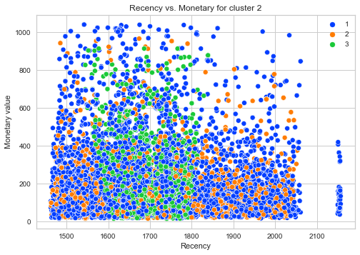

```python
plt.figure()
sns.scatterplot(data=df_2,
                x='days_since_order', y='total_payment_sum',
                hue='review_score', palette='bright')
plt.xlabel('Recency')
plt.ylabel('Monetary value')
plt.legend()
plt.title('Recency vs. Monetary for cluster 2, according to their review score')  # Unsatisfied clients
plt.show()
```

#### Cluster 3

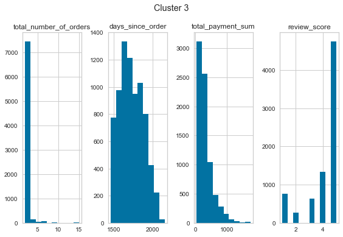

```python
# Cluster 3
fig, (ax1, ax2, ax3, ax4) = plt.subplots(1, 4)
fig.suptitle('Cluster 3')
ax1.hist(df_3['total_number_of_orders'])
ax1.set_title('total_number_of_orders')
ax2.hist(df_3['days_since_order'])
ax2.set_title('days_since_order')
ax3.hist(df_3['total_payment_sum'])
ax3.set_title('total_payment_sum')
ax4.hist(df_3['review_score'])
ax4.set_title('review_score')
plt.tight_layout()
plt.show()
```

[figure not shown]

```python
plt.figure()
sns.scatterplot(data=df_3,
                x='days_since_order', y='total_payment_sum',
                hue='review_score', palette='deep')
plt.xlabel('Recency')
plt.ylabel('Monetary value')
plt.legend()
plt.title('Recency vs. Monetary for cluster 3, according to their review score')
plt.show()
```

#### Cluster 4

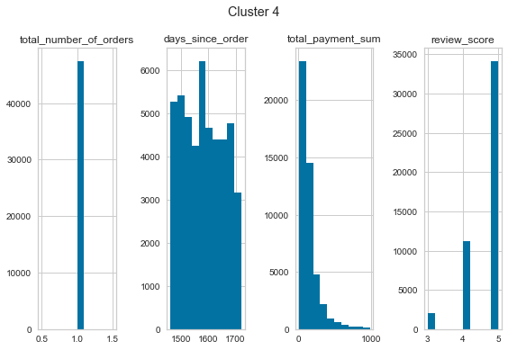

```python
# Cluster 4
fig, (ax1, ax2, ax3, ax4) = plt.subplots(1, 4)
fig.suptitle('Cluster 4')
ax1.hist(df_4['total_number_of_orders'])
ax1.set_title('total_number_of_orders')
ax2.hist(df_4['days_since_order'])
ax2.set_title('days_since_order')
ax3.hist(df_4['total_payment_sum'])
ax3.set_title('total_payment_sum')
ax4.hist(df_4['review_score'])
ax4.set_title('review_score')
plt.tight_layout()
plt.show()
```

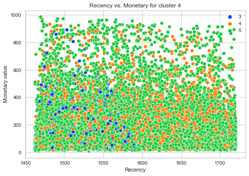

```python
plt.figure()
sns.scatterplot(data=df_4,
                x='days_since_order', y='total_payment_sum',
                hue='review_score', palette='bright')
plt.xlabel('Recency')
plt.ylabel('Monetary value')
plt.legend()
plt.title('Recency vs. Monetary for cluster 4, according to their review score')
plt.show()
```

### Saving clustering dataset

```python
data_bis.head()
```

| customer_unique_id | total_number_of_orders | days_since_order | total_payment_sum | review_score | order_date |
| --- | --- | --- | --- | --- | --- |
| 861eff4711a542e4b93843c6dd7febb0 | 1 | 1932 | 146.87 | 4 | 2017-05-16 |
| 9eae34bbd3a474ec5d07949ca7de67c0 | 1 | 1755 | 275.79 | 1 | 2017-11-09 |
| 9eae34bbd3a474ec5d07949ca7de67c0 | 1 | 1755 | 275.79 | 1 | 2017-11-09 |
| 3c799d181c34d51f6d44bbbc563024db | 1 | 1941 | 140.61 | 3 | 2017-05-07 |
| 23397e992b09769faf5e66f9e171a241 | 1 | 1669 | 137.58 | 4 | 2018-02-03 |

```python
data_5['order_date'] = data_bis['order_date']
```

```python
data_5.head()
```

| customer_unique_id | total_number_of_orders | days_since_order | total_payment_sum | review_score | label | order_date |
| --- | --- | --- | --- | --- | --- | --- |
| 861eff4711a542e4b93843c6dd7febb0 | 1 | 1932 | 146.87 | 4 | 1 | 2017-05-16 |
| 9eae34bbd3a474ec5d07949ca7de67c0 | 1 | 1755 | 275.79 | 1 | 2 | 2017-11-09 |
| 9eae34bbd3a474ec5d07949ca7de67c0 | 1 | 1755 | 275.79 | 1 | 2 | 2017-11-09 |
| 3c799d181c34d51f6d44bbbc563024db | 1 | 1941 | 140.61 | 3 | 1 | 2017-05-07 |
| 23397e992b09769faf5e66f9e171a241 | 1 | 1669 | 137.58 | 4 | 4 | 2018-02-03 |

```python
data_5.to_csv('Segmentation_olist')
```

## Conclusion

Over this project, the clustering of the global Olist dataset was performed using K-Means clustering. 5 clusters were identified and studied in details. The next notebook will present an analysis to determine the maintenance parameters for this clustering model.

## Bonus: Other clustering algorithms tested

### Hierarchical agglomerative clustering

```python
from sklearn.cluster import AgglomerativeClustering
```

```python
# Use of a small sample of the dataset to reduce computation time
X = data.sample(frac=0.3, random_state=7)
data_AC = pd.DataFrame(X)
```

```python
X = StandardScaler().fit_transform(X)
```

```python
X.shape
```

```
(33963, 4)
```

```python
clustering = AgglomerativeClustering(n_clusters=5).fit(X)
```

```python
labels = clustering.labels_
```

```python
data_AC['label'] = clustering.labels_
gb_AC = data_AC.groupby(clustering.labels_)
```

```python
gb_AC.size()
```

```
0     2101
1     2278
2    12431
3     3387
4    13766
dtype: int64
```

```python
gb_AC.mean()
```

|  | total_number_of_orders | days_since_order | total_payment_sum | review_score | label |
| --- | --- | --- | --- | --- | --- |
| 0 | 1.091861 | 1665.411709 | 906.881290 | 4.010947 | 0.0 |
| 1 | 2.233099 | 1728.830992 | 291.015755 | 4.134767 | 1.0 |
| 2 | 1.000000 | 1837.028155 | 132.067845 | 4.639691 | 2.0 |
| 3 | 1.000000 | 1703.255093 | 177.948255 | 1.018601 | 3.0 |
| 4 | 1.000000 | 1585.632791 | 123.581130 | 4.359582 | 4.0 |

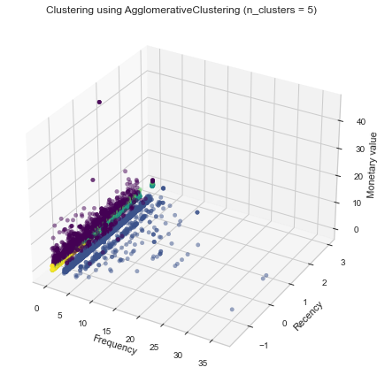

```python
# creating figure
fig = plt.figure()
ax = Axes3D(fig, auto_add_to_figure=False)
fig.add_axes(ax)
# creating the plot
plot_5_clusters = ax.scatter(X[:, 0], X[:, 1], X[:, 2],
                             c=clustering.labels_, alpha=0.5, cmap='viridis')
# setting title and labels
ax.set_title('Clustering using AgglomerativeClustering (n_clusters = 5)')
ax.set_xlabel('Frequency')
ax.set_ylabel('Recency')
ax.set_zlabel('Monetary value')

# displaying the plot
plt.show()
```

```python
from sklearn import metrics
metrics.silhouette_score(X, labels, metric='euclidean')
```

```
0.3553189339543375
```

Hierarchical Agglomerative Clustering could be used, however the calculation time is way more important !

### DBSCAN

```python
from sklearn.cluster import DBSCAN
from sklearn import metrics
from tqdm import tqdm
epsilon_list = np.arange(0.1, 0.5, 0.1)  # List of epsilon values
sample_list = np.arange(5, 25, 5)  # List of min samples number


def GridSearchDBSCAN(epsilon_list, sample_list, X_std):

    # X_std is standard array or df
    silhouette = []
    point = []
    samples = []

    for i in tqdm(range(len(epsilon_list))):
        for k in tqdm(range(len(sample_list))):
            dbscan = DBSCAN(eps=epsilon_list[i], min_samples=sample_list[k])
            dbscan.fit(X_std)
            silh = metrics.silhouette_score(X_std, dbscan.labels_)
            point.append(silh)
            if silh >= max(point):
                silh_coef = silh
                sample = sample_list[k]
        silhouette.append(silh_coef)
        samples.append(sample)

    import matplotlib.pyplot as plt
    plt.plot(epsilon_list, silhouette)
    plt.title("Silhouette score")
    plt.xlabel('epsilon')
    plt.show

    return(epsilon_list, silhouette, samples)
```

```
(array([0.1, 0.2, 0.3, 0.4]),
 [0.3401887243371391,
  0.3948200274790987,
  0.4090196592903897,
  0.41824589045376803],
 [5, 15, 5, 20])
```

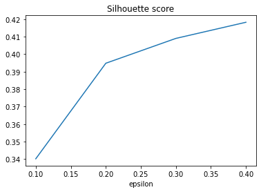

```python
GridSearchDBSCAN(epsilon_list, sample_list, X)
```

```python
from sklearn.cluster import dbscan
y_pred = DBSCAN(eps=0.2, min_samples=15).fit_predict(X)
```

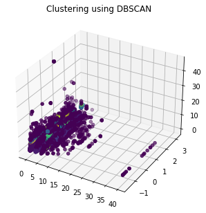

[output not shown]

```python
fig = plt.figure(figsize=(5, 5))
ax = fig.add_subplot(111, projection='3d')
ax.scatter(X[:, 0], X[:, 1], X[:, 2], c=y_pred)
ax.set_title('Clustering using DBSCAN')
plt.show()
```

DBSCAN seems not adapted for this dataframe !